# CMEMS WORKSHOP

Pre-workshop homeworks

Carlo Zampieri

## Disclaimer

Welcome to the workshop on accessing and handling data from the Copernicus Marine Environment Monitoring Service (CMEMS)!

There are a few simple things I need you to do before the workshop, which won’t be discussed on that day. If you have any issue do not hesitate to contact me via mail, so we can fix them in advance.

In particular, you need to:

- register in the Copernicus Marine Service platform
- install all necessary libraries in RStudio (not mandatory)

## User registration

CMEMS provides open and free access to marine data and services. Free registration is required solely for data downloads to track user demographics.

Connect to the [CMEMS homepage](https://marine.copernicus.eu/) (Figure 1) and click the “REGISTER” orange button on the top. Then fill the form (Figure 2) and follow the instructions.

[figure not shown]

Figure 1

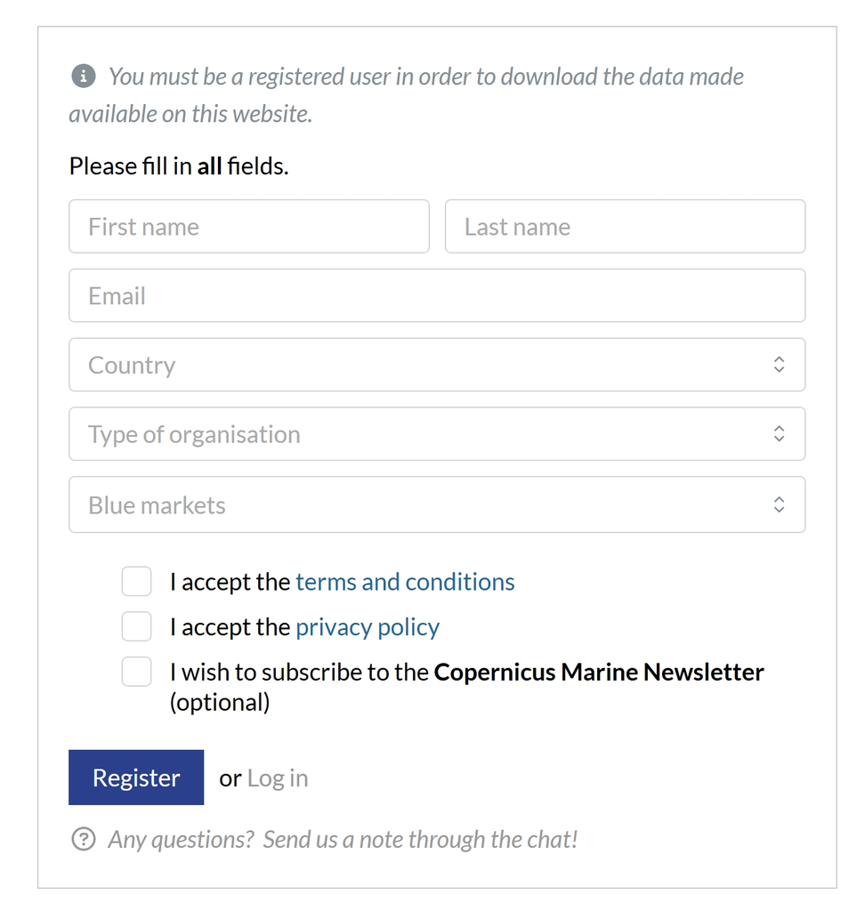

Figure 2

**Note**

The CMEMS website is available in 22 different languages! Click on “English” on the top right corner of the homepage (Figure 1) and select the language you fell more comfortable with.

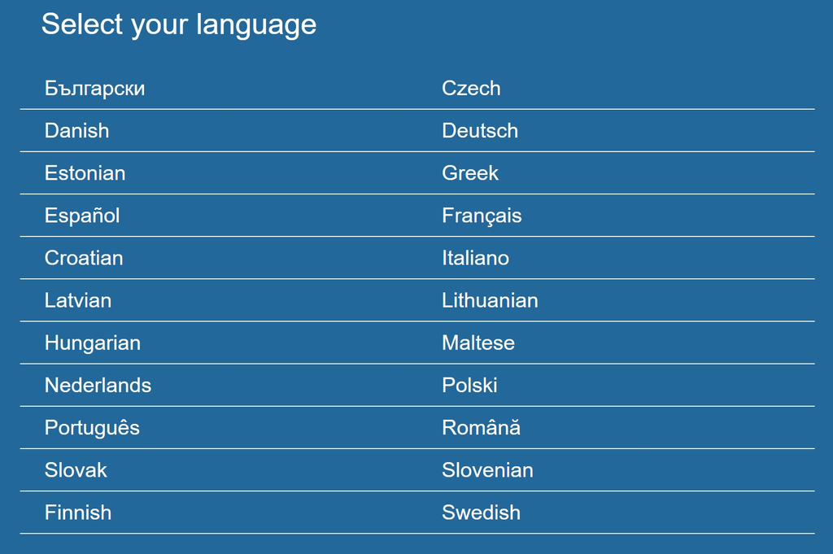

## Prepare your R environment

**This step in not mandatory**

There are multiple ways to handle Copernicus data (GIS, MATLAB, Python, R, etc.). If you don’t plan to use R, you can skip this task.

**For the R beginners**

If you never used R or if you’re a beginner, what is discussed here and some of the stuff we will discuss during the workshop may look a bit confusing: don’t worry it’s normal!

During this workshop, the basics of R and RStudio will be given for granted and we won’t have time to through them. However, you will see that with time and experience everything will start to make sense ;-)

During the workshop we will see how to handle the data you downloaded from the CMEMS catalogue. As I already mentioned there are multiple ways to do that, but we will focus only on the RStudio tools.

There are a few packages you need to install. `terra` and `sf` allow you to work with georeferenced data, while `dplyr` and `tidyr` provide functions to easily handle datasets.

[figure not shown]

To install packages you can use the “Install” button from the “Packages” pane in your RStudio or use the `install.packages()` function as shown below:

```r
install.packages("package.name")
```

**Important**

When you install `sf` and `terra`, a pop-up message will ask you if you want to install the source packages that need to be compiled. Select **YES**.

**Note**

If you already have some of those packages, the installation will run anyway providing you with the most updated version.

If some of those packages are also loaded in your current session, you will be asked to restart the session.

To check that everything went fine, load the packages using the function `library()` as shown in the box below. If don’t get any error message it means that you’re ready for the workshop ;-)

```r
library(dplyr)
library(tidyr)
library(terra)
library(sf)
```